# Задачи по Эконометрике: Доверительные интервалы

Н.В. Артамонов (МГИМО МИД России)

# 1 Построение доверительных интервалов

## 1.1 sleep equation

Для набора данных `sleep75` рассмотрим линейную регрессию **sleep ~ 1 + totwrk + age + south + male + smsa + yngkid + marr**.

Постройте 90%-доверительные интервалы (неробастные и робастные) для каждого коэффициента. **Ответ округлите до 3-х десятичных знаков.**

Ответ (неробастные)

```
                 5 %     95 %
(Intercept) 3317.954 3583.872
totwrk        -0.199   -0.139
age            0.269    5.109
south         32.662  170.475
male          29.851  145.487
smsa        -109.302   -0.193
yngkid       -96.876   68.952
marr         -38.349  100.770
```

Ответ (робастные)

```
                 5 %     95 %
(Intercept) 3301.820 3600.005
totwrk        -0.203   -0.136
age            0.318    5.061
south         31.548  171.588
male          28.619  146.719
smsa        -109.835    0.340
yngkid      -103.344   75.419
marr         -44.867  107.289
```

## 1.2 output equation

Для набора данных `Labour` рассмотрим линейную регрессию **log(output) ~ 1 + log(capital) + log(labour)**.

Постройте 95%-доверительные интервалы (неробастные и робастные) для каждого коэффициента. **Ответ округлите до 3-х десятичных знаков.**

Ответ (неробастные)

```
              2.5 % 97.5 %
(Intercept)  -1.901 -1.522
log(capital)  0.174  0.241
log(labour)   0.669  0.760
```

Ответ (робастные)

```
              2.5 % 97.5 %
(Intercept)  -2.073 -1.350
log(capital)  0.146  0.270
log(labour)   0.629  0.801
```

## 1.3 cost equation

Для набора данных `Electricity` рассмотрим линейную регрессию **log(cost) ~ 1 + log(q) + I(log(q)^2) + log(pl) + log(pk) + log(pf)**.

Постройте 99%-доверительные интервалы (неробастные и робастные) для каждого коэффициента. **Ответ округлите до 3-х десятичных знаков.**

Ответ (неробастные)

```
             0.5 % 99.5 %
(Intercept) -8.581 -4.896
log(q)       0.320  0.486
I(log(q)^2)  0.025  0.036
log(pl)     -0.038  0.330
log(pk)      0.007  0.308
log(pf)      0.573  0.796
```

Ответ (робастные)

```
             0.5 % 99.5 %
(Intercept) -8.949 -4.529
log(q)       0.230  0.576
I(log(q)^2)  0.020  0.041
log(pl)     -0.077  0.369
log(pk)     -0.005  0.320
log(pf)      0.549  0.820
```

# 2 Доверительные интервалы и t-тест

## 2.1 sleep equation

Для набора данных `sleep75` рассмотрим линейную регрессию **sleep на totwrk, age, age^2, south, male, smsa, yngkid, marr, union**.

Ниже приведены (неробастные) 90%-доверительные интервалы для коэффициентов.

```
                 5 %     95 %
(Intercept) 3269.356 4007.222
totwrk        -0.197   -0.137
age          -26.347   11.084
I(age^2)      -0.098    0.347
south         31.483  169.733
male          28.681  144.571
smsa        -108.584    0.775
yngkid      -101.543   65.622
marr         -34.936  104.904
union        -49.590   76.328
```

Какие коэффициенты значимы при уровне значимости 10%? Ответ

```
======================
Коэффициент Значимость
----------------------
(Intercept)   Значим
totwrk        Значим
age          Незначим
I(age2)      Незначим
south         Значим
male          Значим
smsa         Незначим
yngkid       Незначим
marr         Незначим
union        Незначим
----------------------
```

Визуализация доверительных интервалов как есть (в одном масштабе)

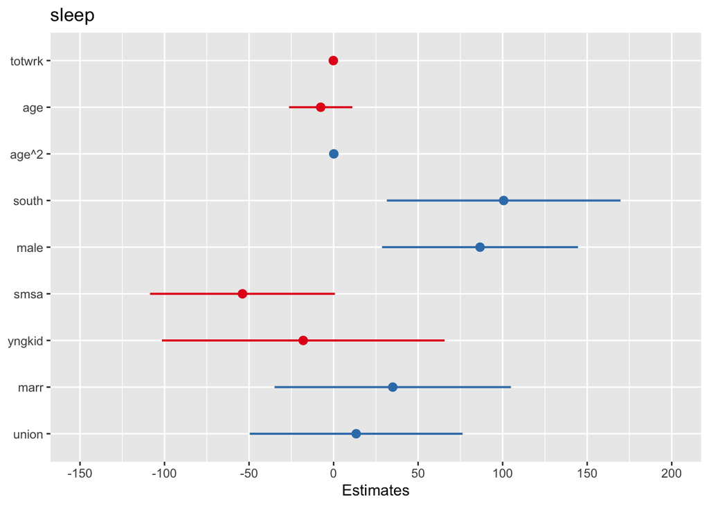

Шкалированные доверительные интервалы

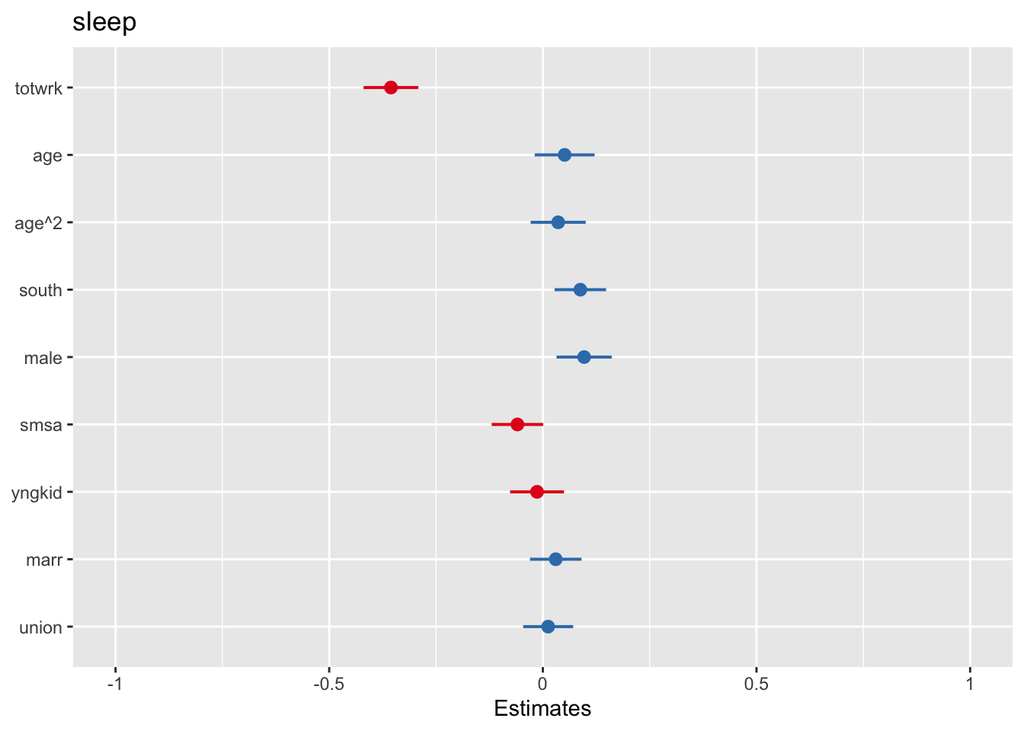

## 2.2 cost equation

Для набора данных `Electricity` рассмотрим линейную регрессию **log(cost) на log(q), log^2(q), log(pl), log^2(pl), log(pk), log^2(pk), log(pf), log^2(pf)**

Ниже приведены (робастные) 99%-доверительные интервалы для коэффициентов.

```
                0.5 % 99.5 %
(Intercept)  -129.940 41.133
log(q)          0.223  0.570
I(log(q)^2)     0.020  0.042
log(pl)       -11.254 27.921
I(log(pl)^2)   -1.544  0.633
log(pk)        -3.795  4.668
I(log(pk)^2)   -0.559  0.487
log(pf)        -3.909  5.707
I(log(pf)^2)   -0.734  0.673
```

Какие коэффициенты значимы при уровне значимости 1%? Ответ

```
======================
Коэффициент Значимость
----------------------
(Intercept)  Незначим
log(q)        Значим
I(log(q)2)    Значим
log(pl)      Незначим
I(log(pl)2)  Незначим
log(pk)      Незначим
I(log(pk)2)  Незначим
log(pf)      Незначим
I(log(pf)2)  Незначим
----------------------
```

Визуализация доверительных интервалов как есть (в одном масштабе)

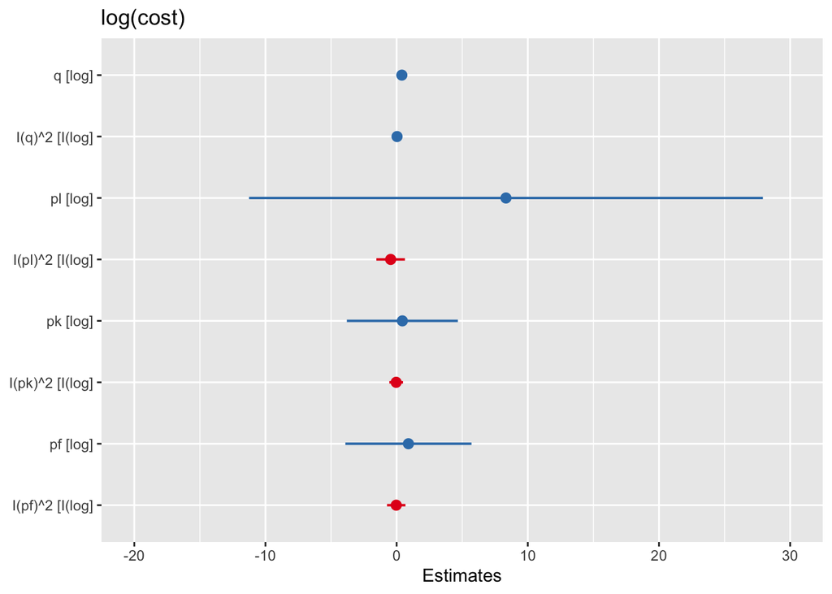

Шкалированные доверительные интервалы

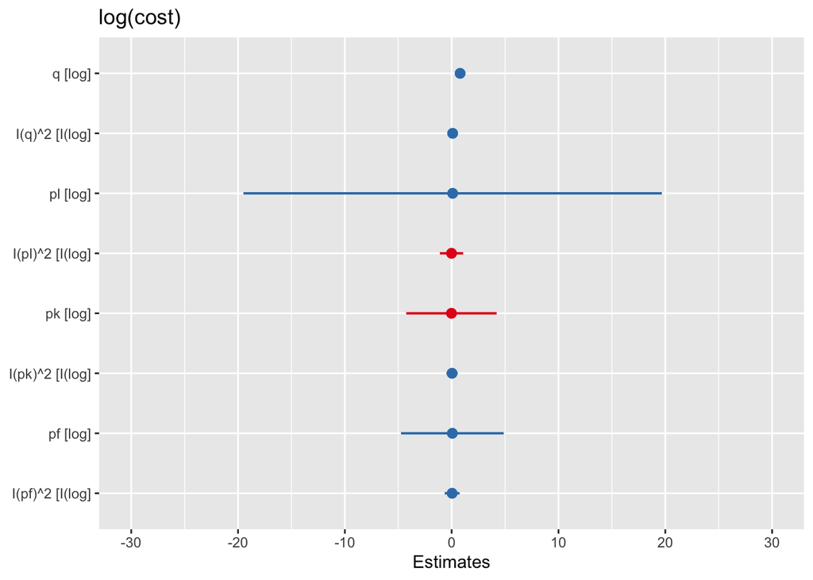

# 3 Доверителные интервалы и сравнение моделей

Результаты подгонки:

```
=======================================================
                            Dependent variable:
                    -----------------------------------
                                   sleep
                       Север        Юг         общая
                        (1)         (2)         (3)
-------------------------------------------------------
totwrk               -0.159***    -0.074     -0.147***
                      (0.018)     (0.045)     (0.017)

age                   -5.507      -12.882     -8.675
                     (12.557)    (25.039)    (11.271)

I(age2)                0.084       0.273       0.140
                      (0.150)     (0.299)     (0.135)

smsa                 -59.812*     16.055     -69.924**
                     (35.379)    (96.789)    (32.330)

marr                  28.034     152.296*     47.598
                     (46.960)    (86.153)    (41.450)

Constant            3664.188*** 3435.410*** 3675.413***
                     (244.380)   (494.979)   (219.803)

-------------------------------------------------------
Observations            576         130         706
R2                     0.129       0.140       0.118
Adjusted R2            0.122       0.106       0.112
Residual Std. Error   421.078     393.300     418.809
F Statistic          16.928***   4.043***    18.768***
=======================================================
Note:                       *p<0.1; **p<0.05; ***p<0.01
```

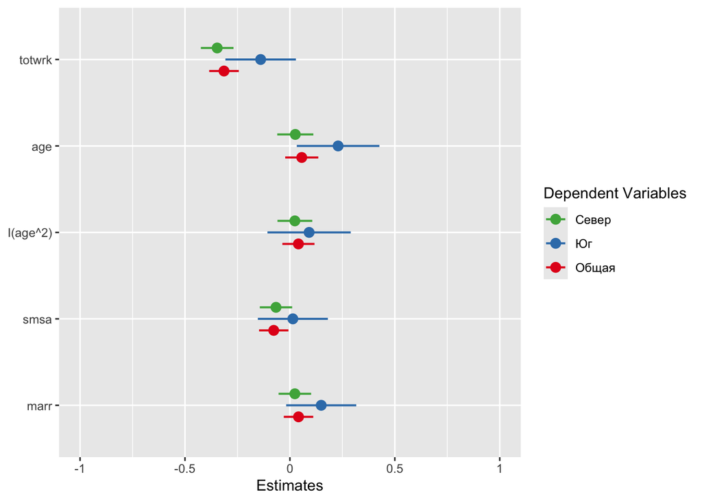